# baseline_cnn

##### Baseline Model: Implementation and Rationale

##### 1. Goal of the Baseline

The aim of our baseline model was to quickly establish a from-scratch convolutional network to confirm our dataset loading, shape consistency, and minimal data augmentation pipeline. By building a small "two-block CNN," we gain an early reference point (both in accuracy and training behavior) before applying more sophisticated or pretrained approaches.

##### 2. Architectural Decisions

- **Input Shape**: (180,180,3) to align with image_dataset_from_directory(..., image_size=(180,180))
- **Two Convolution Blocks**:
  - Each block has Conv2D(32,3) or Conv2D(64,3) repeated twice, then a MaxPooling2D
  - This standard pattern follows a typical VGG-like design, albeit in a smaller scale
- **Flatten → Dense**:
  - We flatten the pooled feature maps, then apply a Dense(128, relu) with a Dropout(0.5) for partial regularization
  - Lastly, a Dense(num_classes, softmax) for multi-class classification

##### 3. Data Augmentation

Before the first convolution block, we incorporate Keras's built-in augmentation layers:

- RandomFlip horizontally
- RandomRotation ~10%
- RandomZoom ~10%

These transformations help the model learn invariance to flips, minor rotation, and scale changes, presumably beneficial given our limited dataset sizes (~100–172 images per class).

##### 5. Future Enhancements

- **Hyperparameter Tuning**: Investigate a smaller or variable learning rate, or experiment with an additional conv block for deeper feature extraction
- **Transfer Learning**: As recommended in our roadmap, consider using a pretrained network (e.g., VGG16 or MobileNet). This often boosts accuracy for small or moderate datasets
- **Offline Augmentation**: Potentially expand the dataset with the separate offline augmentation script—generating more samples to reduce overfitting

##### 6. Conclusion and Next Steps

The baseline model proves that a simple two-block CNN, plus minimal on-the-fly augmentation, yields a workable solution. This foundation is well-suited for iterative refinement—either by adjusting hyperparameters or transitioning to a more advanced Transfer Learning pipeline—as guided by our overall project roadmap.

```python
%pip install tensorflow
%pip install matplotlib
%pip install numpy
%pip install scikit-learn
```

```
Found 457 files belonging to 3 classes.
Found 144 files belonging to 3 classes.
Found 154 files belonging to 3 classes.
```

```
Model: "BaselineCNN"
```

```
┏━━━━━━━━━━━━━━━━━━━━━━━━━━━━━━━━━┳━━━━━━━━━━━━━━━━━━━━━━━━┳━━━━━━━━━━━━━━━┓
┃ Layer (type)                    ┃ Output Shape           ┃       Param # ┃
┡━━━━━━━━━━━━━━━━━━━━━━━━━━━━━━━━━╇━━━━━━━━━━━━━━━━━━━━━━━━╇━━━━━━━━━━━━━━━┩
│ input_image (InputLayer)        │ (None, 180, 180, 3)    │             0 │
├─────────────────────────────────┼────────────────────────┼───────────────┤
│ MyDataAug (Sequential)          │ (None, 180, 180, 3)    │             0 │
├─────────────────────────────────┼────────────────────────┼───────────────┤
│ conv2d (Conv2D)                 │ (None, 180, 180, 32)   │           896 │
├─────────────────────────────────┼────────────────────────┼───────────────┤
│ conv2d_1 (Conv2D)               │ (None, 180, 180, 32)   │         9,248 │
├─────────────────────────────────┼────────────────────────┼───────────────┤
│ max_pooling2d (MaxPooling2D)    │ (None, 90, 90, 32)     │             0 │
├─────────────────────────────────┼────────────────────────┼───────────────┤
│ conv2d_2 (Conv2D)               │ (None, 90, 90, 64)     │        18,496 │
├─────────────────────────────────┼────────────────────────┼───────────────┤
│ conv2d_3 (Conv2D)               │ (None, 90, 90, 64)     │        36,928 │
├─────────────────────────────────┼────────────────────────┼───────────────┤
│ max_pooling2d_1 (MaxPooling2D)  │ (None, 45, 45, 64)     │             0 │
├─────────────────────────────────┼────────────────────────┼───────────────┤
│ flatten (Flatten)               │ (None, 129600)         │             0 │
├─────────────────────────────────┼────────────────────────┼───────────────┤
│ dense (Dense)                   │ (None, 128)            │    16,588,928 │
├─────────────────────────────────┼────────────────────────┼───────────────┤
│ dropout (Dropout)               │ (None, 128)            │             0 │
├─────────────────────────────────┼────────────────────────┼───────────────┤
│ dense_1 (Dense)                 │ (None, 3)              │           387 │
└─────────────────────────────────┴────────────────────────┴───────────────┘
```

```
 Total params: 16,654,883 (63.53 MB)
```

```
 Trainable params: 16,654,883 (63.53 MB)
```

```
 Non-trainable params: 0 (0.00 B)
```

```
15/15 ━━━━━━━━━━━━━━━━━━━━ 0s 513ms/step - accuracy: 0.3692 - loss: 278.9919
```

```
WARNING:absl:You are saving your model as an HDF5 file via `model.save()` or `keras.saving.save_model(model)`. This file format is considered legacy. We recommend using instead the native Keras format, e.g. `model.save('my_model.keras')` or `keras.saving.save_model(model, 'my_model.keras')`.
```

```
15/15 ━━━━━━━━━━━━━━━━━━━━ 9s 575ms/step - accuracy: 0.3711 - loss: 269.9249 - val_accuracy: 0.5069 - val_loss: 1.2182
15/15 ━━━━━━━━━━━━━━━━━━━━ 0s 673ms/step - accuracy: 0.5656 - loss: 0.9462
```

```
WARNING:absl:You are saving your model as an HDF5 file via `model.save()` or `keras.saving.save_model(model)`. This file format is considered legacy. We recommend using instead the native Keras format, e.g. `model.save('my_model.keras')` or `keras.saving.save_model(model, 'my_model.keras')`.
```

```
15/15 ━━━━━━━━━━━━━━━━━━━━ 11s 749ms/step - accuracy: 0.5656 - loss: 0.9446 - val_accuracy: 0.7014 - val_loss: 0.7083
15/15 ━━━━━━━━━━━━━━━━━━━━ 0s 816ms/step - accuracy: 0.6459 - loss: 0.7838
```

```
WARNING:absl:You are saving your model as an HDF5 file via `model.save()` or `keras.saving.save_model(model)`. This file format is considered legacy. We recommend using instead the native Keras format, e.g. `model.save('my_model.keras')` or `keras.saving.save_model(model, 'my_model.keras')`.
```

```
15/15 ━━━━━━━━━━━━━━━━━━━━ 14s 895ms/step - accuracy: 0.6465 - loss: 0.7859 - val_accuracy: 0.6806 - val_loss: 0.6920
15/15 ━━━━━━━━━━━━━━━━━━━━ 13s 831ms/step - accuracy: 0.6652 - loss: 0.7544 - val_accuracy: 0.6875 - val_loss: 0.7130
15/15 ━━━━━━━━━━━━━━━━━━━━ 0s 812ms/step - accuracy: 0.5838 - loss: 0.9427
```

```
WARNING:absl:You are saving your model as an HDF5 file via `model.save()` or `keras.saving.save_model(model)`. This file format is considered legacy. We recommend using instead the native Keras format, e.g. `model.save('my_model.keras')` or `keras.saving.save_model(model, 'my_model.keras')`.
```

```
15/15 ━━━━━━━━━━━━━━━━━━━━ 13s 882ms/step - accuracy: 0.5858 - loss: 0.9381 - val_accuracy: 0.7778 - val_loss: 0.5346
15/15 ━━━━━━━━━━━━━━━━━━━━ 13s 870ms/step - accuracy: 0.5381 - loss: 7.5380 - val_accuracy: 0.7292 - val_loss: 0.6102
15/15 ━━━━━━━━━━━━━━━━━━━━ 14s 895ms/step - accuracy: 0.5873 - loss: 2.1275 - val_accuracy: 0.7083 - val_loss: 0.8159
15/15 ━━━━━━━━━━━━━━━━━━━━ 0s 763ms/step - accuracy: 0.6870 - loss: 0.7045
```

```
WARNING:absl:You are saving your model as an HDF5 file via `model.save()` or `keras.saving.save_model(model)`. This file format is considered legacy. We recommend using instead the native Keras format, e.g. `model.save('my_model.keras')` or `keras.saving.save_model(model, 'my_model.keras')`.
```

```
15/15 ━━━━━━━━━━━━━━━━━━━━ 13s 842ms/step - accuracy: 0.6886 - loss: 0.7034 - val_accuracy: 0.8333 - val_loss: 0.4530
15/15 ━━━━━━━━━━━━━━━━━━━━ 0s 804ms/step - accuracy: 0.7388 - loss: 0.6577
```

```
WARNING:absl:You are saving your model as an HDF5 file via `model.save()` or `keras.saving.save_model(model)`. This file format is considered legacy. We recommend using instead the native Keras format, e.g. `model.save('my_model.keras')` or `keras.saving.save_model(model, 'my_model.keras')`.
```

```
15/15 ━━━━━━━━━━━━━━━━━━━━ 14s 884ms/step - accuracy: 0.7381 - loss: 0.6567 - val_accuracy: 0.8264 - val_loss: 0.4324
15/15 ━━━━━━━━━━━━━━━━━━━━ 0s 777ms/step - accuracy: 0.6912 - loss: 1.0076
```

```
WARNING:absl:You are saving your model as an HDF5 file via `model.save()` or `keras.saving.save_model(model)`. This file format is considered legacy. We recommend using instead the native Keras format, e.g. `model.save('my_model.keras')` or `keras.saving.save_model(model, 'my_model.keras')`.
```

```
15/15 ━━━━━━━━━━━━━━━━━━━━ 13s 850ms/step - accuracy: 0.6889 - loss: 1.0248 - val_accuracy: 0.8542 - val_loss: 0.4314

Evaluating on test set ...
5/5 ━━━━━━━━━━━━━━━━━━━━ 1s 185ms/step - accuracy: 0.7931 - loss: 0.5251
Test loss: 0.4888
Test accuracy: 0.8312
```

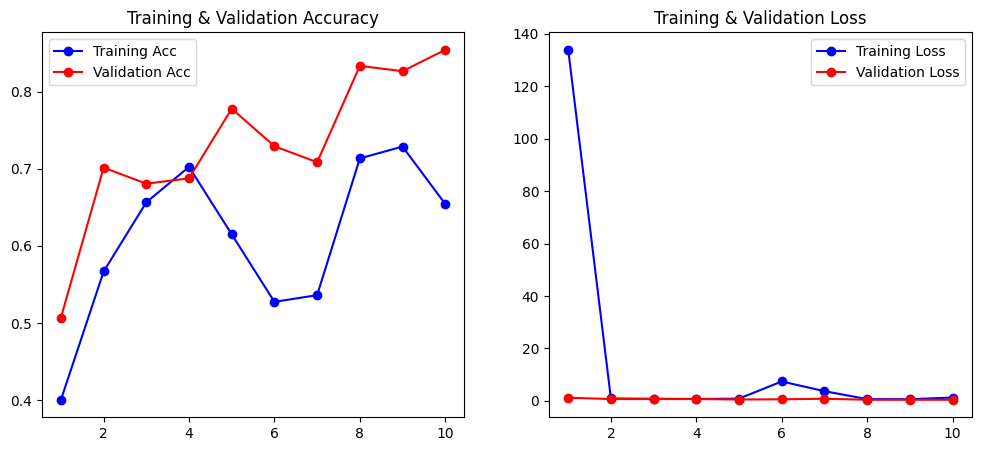

```
Generating confusion matrix ...
1/1 ━━━━━━━━━━━━━━━━━━━━ 0s 288ms/step
1/1 ━━━━━━━━━━━━━━━━━━━━ 0s 164ms/step
1/1 ━━━━━━━━━━━━━━━━━━━━ 0s 193ms/step
1/1 ━━━━━━━━━━━━━━━━━━━━ 0s 182ms/step
1/1 ━━━━━━━━━━━━━━━━━━━━ 0s 194ms/step
Confusion Matrix:
 [[26  2  4]
 [ 6 60  2]
 [ 2 10 42]]
Classification Report:
               precision    recall  f1-score   support

           0       0.76      0.81      0.79        32
           1       0.83      0.88      0.86        68
           2       0.88      0.78      0.82        54

    accuracy                           0.83       154
   macro avg       0.82      0.82      0.82       154
weighted avg       0.83      0.83      0.83       154
```

```
2025-01-25 13:06:56.865287: I tensorflow/core/framework/local_rendezvous.cc:405] Local rendezvous is aborting with status: OUT_OF_RANGE: End of sequence
```

```python
#!/usr/bin/env python
# baseline_implementation_no_dip.py

import os
import numpy as np
import matplotlib.pyplot as plt
import cv2

import tensorflow as tf
from tensorflow import keras
from tensorflow.keras import layers

###########################################################################
# Data Augmentation Pipeline
###########################################################################
myDataAug = keras.Sequential([
    layers.RandomFlip("horizontal"),
    layers.RandomRotation(0.1),
    layers.RandomZoom(0.1),
    # You can add layers.RandomContrast(0.1) if desired.
], name="MyDataAug")

###########################################################################
# Baseline CNN Model: repeated 3×3 conv + maxpool
###########################################################################
def build_baseline_cnn(num_classes=3, input_shape=(180,180,3)):
    """
    Basic CNN: repeated 3x3 conv -> maxpool -> flatten -> dense.
    """
    # The input shape is (180,180,3) to match your dataset resizing
    inputs = keras.Input(shape=input_shape, name="input_image")

    # (Optional) Data augmentation first
    x = myDataAug(inputs)

    # 1st conv block
    x = layers.Conv2D(32, kernel_size=3, padding='same', activation='relu')(x)
    x = layers.Conv2D(32, kernel_size=3, padding='same', activation='relu')(x)
    x = layers.MaxPooling2D()(x)

    # 2nd conv block
    x = layers.Conv2D(64, kernel_size=3, padding='same', activation='relu')(x)
    x = layers.Conv2D(64, kernel_size=3, padding='same', activation='relu')(x)
    x = layers.MaxPooling2D()(x)

    # (Optional) 3rd conv block
    # x = layers.Conv2D(128, kernel_size=3, padding='same', activation='relu')(x)
    # x = layers.Conv2D(128, kernel_size=3, padding='same', activation='relu')(x)
    # x = layers.MaxPooling2D()(x)

    # Flatten and dense
    x = layers.Flatten()(x)
    x = layers.Dense(128, activation='relu')(x)
    x = layers.Dropout(0.5)(x)

    outputs = layers.Dense(num_classes, activation='softmax')(x)
    model = keras.Model(inputs, outputs, name="BaselineCNN")
    return model

###########################################################################
# Main
###########################################################################
def main():
    # 1) Paths
    train_dir = "/Users/ryangichuru/Documents/SSD-K/Uni/2nd year/Intro to AI/CNN/assignment-2-ryantigi254-main/data/Output Data/train"
    val_dir   = "/Users/ryangichuru/Documents/SSD-K/Uni/2nd year/Intro to AI/CNN/assignment-2-ryantigi254-main/data/Output Data/val"
    test_dir  = "/Users/ryangichuru/Documents/SSD-K/Uni/2nd year/Intro to AI/CNN/assignment-2-ryantigi254-main/data/Output Data/test"

    # 2) Load Datasets
    batch_size = 32
    img_size = (180, 180)

    train_ds = tf.keras.preprocessing.image_dataset_from_directory(
        train_dir,
        image_size=img_size,
        batch_size=batch_size,
        label_mode='categorical'
    )
    val_ds = tf.keras.preprocessing.image_dataset_from_directory(
        val_dir,
        image_size=img_size,
        batch_size=batch_size,
        label_mode='categorical'
    )
    test_ds = tf.keras.preprocessing.image_dataset_from_directory(
        test_dir,
        image_size=img_size,
        batch_size=batch_size,
        label_mode='categorical'
    )

    # 3) Build model
    num_classes = 3  # e.g. 3 people or classes
    baseline_model = build_baseline_cnn(num_classes=num_classes,
                                        input_shape=(180,180,3))
    baseline_model.summary()

    # 4) Compile
    baseline_model.compile(optimizer='rmsprop',
                           loss='categorical_crossentropy',
                           metrics=['accuracy'])

    # 5) Train
    callbacks_list = [
        keras.callbacks.ModelCheckpoint("baseline_cnn_best.h5",
                                        save_best_only=True,
                                        monitor="val_loss")
    ]
    epochs = 10
    history = baseline_model.fit(
        train_ds,
        validation_data=val_ds,
        epochs=epochs,
        callbacks=callbacks_list
    )

    # 6) Evaluate on test set
    print("\nEvaluating on test set ...")
    test_loss, test_acc = baseline_model.evaluate(test_ds)
    print(f"Test loss: {test_loss:.4f}")
    print(f"Test accuracy: {test_acc:.4f}")

    # 7) Plot training vs. validation
    acc = history.history['accuracy']
    val_acc = history.history['val_accuracy']
    loss = history.history['loss']
    val_loss = history.history['val_loss']
    epochs_range = range(1, len(acc)+1)

    plt.figure(figsize=(12,5))
    plt.subplot(1,2,1)
    plt.plot(epochs_range, acc, 'bo-', label='Training Acc')
    plt.plot(epochs_range, val_acc, 'ro-', label='Validation Acc')
    plt.title('Training & Validation Accuracy')
    plt.legend()

    plt.subplot(1,2,2)
    plt.plot(epochs_range, loss, 'bo-', label='Training Loss')
    plt.plot(epochs_range, val_loss, 'ro-', label='Validation Loss')
    plt.title('Training & Validation Loss')
    plt.legend()
    plt.show()

    # 8) Confusion Matrix
    print("\nGenerating confusion matrix ...")
    all_labels = []
    all_preds = []
    for images, labels in test_ds:
        preds = baseline_model.predict(images)
        all_preds.extend(tf.argmax(preds, axis=1).numpy())
        all_labels.extend(tf.argmax(labels, axis=1).numpy())

    from sklearn.metrics import confusion_matrix, classification_report
    cm = confusion_matrix(all_labels, all_preds)
    print("Confusion Matrix:\n", cm)
    print("Classification Report:\n",
          classification_report(all_labels, all_preds))

if __name__ == "__main__":
    main()
```